# Final project: Joe Biden’s tweets sentiment analysis

Lexi Luo, Shuyuan Jia, Isabella Xue, Ruohe Zhou

Thesis Statement: Based on sentiment analysis, we hypothesize that President Joe Biden’s tweets tend to be more positive before he announced running for presidency on April 25, 2019.

```r
options(warn=-1)
library(tidytext)
library(data.table)
library(lubridate)
```

```r
library(ggplot2)
library(tidyverse)
library(wordcloud)
library(RColorBrewer)
```

bitweet_pre is the pre_nomination data

```r
bitweet<- fread("JoeBidenTweets.csv") %>% as.tbl
bitweet_pre <- bitweet %>%
  filter(timestamp < '2019-04-25 00:00')
text_df_pre <- tibble(tweet = 1:nrow(bitweet_pre), text = bitweet_pre$tweet)
```

bitweet_post is the post_nomination data

```r
bitweet_post <- bitweet %>%
  filter(timestamp > '2019-04-25 00:00')
text_df_post <- tibble(tweet = 1:nrow(bitweet_post), text = bitweet_post$tweet)
```

Data Cleaning

```r
text_df_pre$text <- gsub("https\\S*", "", text_df_pre$text)
text_df_pre$text <-gsub("@\\S*", "", text_df_pre$text)
text_df_pre$text <-gsub("amp", "", text_df_pre$text)
text_df_pre$text <-gsub("[\r\n]", "", text_df_pre$text)
text_df_pre$text <-gsub("[[:punct:]]", "", text_df_pre$text)
text_df_pre$text <-gsub("the", "", text_df_pre$text)
text_df_pre$text <-gsub("to", "", text_df_pre$text)
text_df_pre$text <-gsub("and", "", text_df_pre$text)
text_df_pre$text <-gsub("in", "", text_df_pre$text)
text_df_pre$text <-gsub("a", "", text_df_pre$text)
text_df_pre$text <-gsub("of", "", text_df_pre$text)
text_df_pre$text <-gsub("is", "", text_df_pre$text)
text_df_pre$text <-gsub("for", "", text_df_pre$text)
text_df_pre$text <-gsub("on", "", text_df_pre$text)
text_df_pre$text <-gsub("are", "", text_df_pre$text)
text_df_pre$text <-gsub("at", "", text_df_pre$text)
text_df_pre$text <-gsub("with", "", text_df_pre$text)
text_df_pre$text <-gsub("from", "", text_df_pre$text)

text_df_post$text <- gsub("https\\S*", "", text_df_post$text)
text_df_post$text <- gsub("@\\S*", "", text_df_post$text)
text_df_post$text <- gsub("amp", "", text_df_post$text)
text_df_post$text <- gsub("[\r\n]", "", text_df_post$text)
text_df_post$text <- gsub("[[:punct:]]", "", text_df_post$text)
text_df_post$text <-gsub("the", "", text_df_post$text)
text_df_post$text <-gsub("to", "", text_df_post$text)
text_df_post$text <-gsub("and", "", text_df_post$text)
text_df_post$text <-gsub("in", "", text_df_post$text)
text_df_post$text <-gsub("a", "", text_df_post$text)
text_df_post$text <-gsub("of", "", text_df_post$text)
text_df_post$text <-gsub("is", "", text_df_post$text)
text_df_post$text <-gsub("for", "", text_df_post$text)
text_df_post$text <-gsub("on", "", text_df_post$text)
text_df_post$text <-gsub("are", "", text_df_post$text)
text_df_post$text <-gsub("at", "", text_df_post$text)
text_df_post$text <-gsub("with", "", text_df_post$text)
text_df_post$text <-gsub("from", "", text_df_post$text)

tword_pre  = text_df_pre %>% unnest_tokens(word, text)
tword_post = text_df_post %>% unnest_tokens(word, text)
```

WordCloud

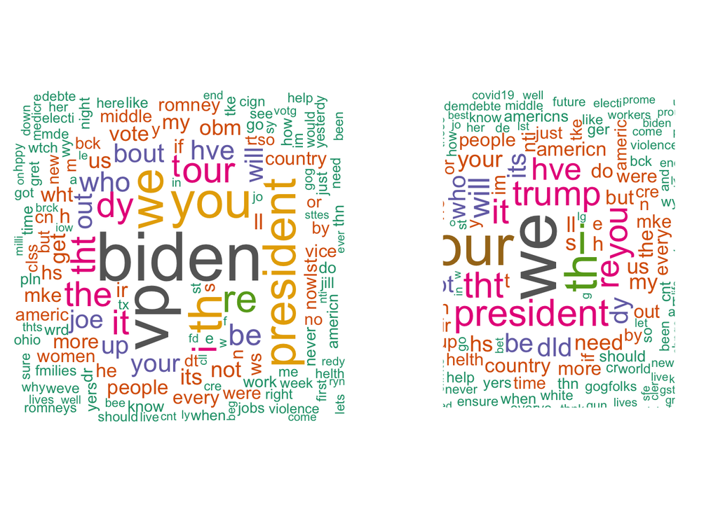

```r
par(mfrow=c(1,2))
words_pre <- tword_pre %>% count(word, sort=TRUE)
words_post <- tword_post%>% count(word, sort=TRUE)
wordcloud(words = words_pre$word, freq = words_pre$n, min.freq = 1,max.words=200, random.order=FALSE, rot.per=0.35,            colors=brewer.pal(8, "Dark2"))
wordcloud(words = words_post$word, freq = words_post$n, min.freq = 1,max.words=200, random.order=FALSE, rot.per=0.35,            colors=brewer.pal(8, "Dark2"))
```

Description: We observed that before running for presidency, the most frequent words that showed up in Biden’s tweets were “biden”, “president”, “you”, and “we”. After the announcement of running for presidency, the most frequent words changed to “Trump” and “our”, with“president” and “we” remained as highly frequent words. Considering that the tweets after running for presidency might contain more information related to his opponent Trump, It’s possible that the tweets after running for presidency became less positive.

```r
bing <- get_sentiments("bing") %>%
  mutate(neg= sentiment == "negative",
         pos = sentiment =="positive")

tword_bing_pre = tword_pre %>%
  left_join(bing) %>%
  group_by(tweet) %>%
  summarize(bingNeg = sum(neg, na.rm = T),
            bingPos = sum(pos, na.rm = T),
            bingWords = bingNeg + bingPos,
            bing = bingPos/(bingWords+.00000001))
tword_bing_post = tword_post %>%
  left_join(bing) %>%
  group_by(tweet) %>%
  summarize(bingNeg = sum(neg, na.rm = T),
            bingPos = sum(pos, na.rm = T),
            bingWords = bingNeg + bingPos,
            bing = bingPos/(bingWords+.00000001))
require(gridExtra)
```

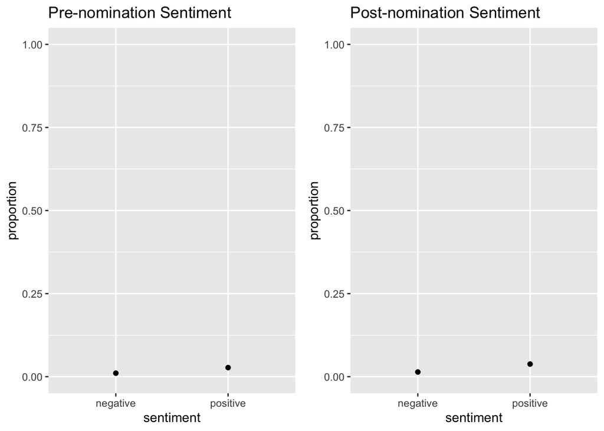

```r
data_bing_pre <- data.frame(sentiment = c('negative', 'positive'),
                        proportion = c(sum(tword_bing_pre$bingNeg)/nrow(tword_pre),
                                  sum(tword_bing_pre$bingPos)/nrow(tword_pre)))
data_bing_post <- data.frame(sentiment = c('negative', 'positive'),
                        proportion = c(sum(tword_bing_post$bingNeg)/nrow(tword_post),
                                  sum(tword_bing_post$bingPos)/nrow(tword_post)))
bing1<-ggplot(data_bing_pre, aes(x = sentiment, y = proportion)) + geom_point() + ggtitle('Pre-nomination Sentiment') + ylim(0,1)
bing2<-ggplot(data_bing_post, aes(x = sentiment, y = proportion)) + geom_point() + ggtitle('Post-nomination Sentiment') + ylim(0,1)
grid.arrange(bing1, bing2, ncol=2)
```

Description: In this graph made by implementing the bing method, the proportion of positive words showed up in the tweets after running for presidency seems to be very slightly larger.

```r
lough = get_sentiments("loughran") %>%
  rename(lough = sentiment)

lough = lough %>%
  mutate(value = 1) %>%
  pivot_wider(word, names_from = lough)

loughFeat_pre = tword_pre %>%
  left_join(lough) %>%
  group_by(tweet) %>%
  summarize(
    neg = sum(negative, na.rm=T),
    pos = sum(positive, na.rm=T),
    Uncertain = sum(uncertainty, na.rm=T),
    litious = sum(litigious, na.rm=T),
    Constraining = sum(constraining, na.rm=T),
    superfluous = sum(superfluous, na.rm=T))
loughFeat_post = tword_post %>%
  left_join(lough) %>%
  group_by(tweet) %>%
  summarize(
    neg = sum(negative, na.rm=T),
    pos = sum(positive, na.rm=T),
    Uncertain = sum(uncertainty, na.rm=T),
    litious = sum(litigious, na.rm=T),
    Constraining = sum(constraining, na.rm=T),
    superfluous = sum(superfluous, na.rm=T))
```

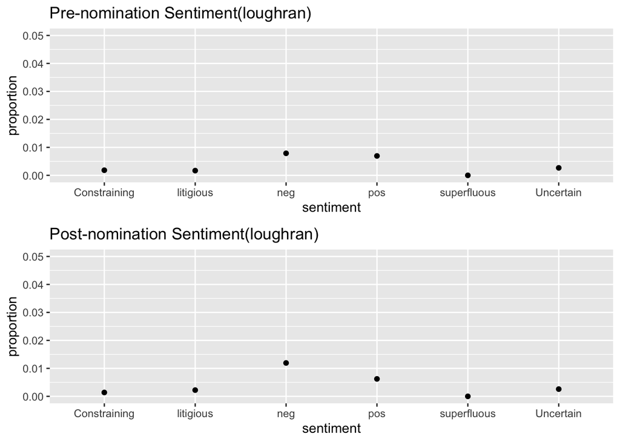

```r
data_lough_pre <- data.frame(sentiment = c('neg','pos','Uncertain','litigious','Constraining','superfluous'), proportion =
                         c(sum(loughFeat_pre$neg, na.rm=T)/nrow(tword_pre),
                           sum(loughFeat_pre$pos, na.rm=T)/nrow(tword_pre),
                           sum(loughFeat_pre$Uncertain, na.rm=T)/nrow(tword_pre),
                           sum(loughFeat_pre$litious, na.rm=T)/nrow(tword_pre),
                           sum(loughFeat_pre$Constraining, na.rm=T)/nrow(tword_pre),
                           sum(loughFeat_pre$superfluous, na.rm=T)/nrow(tword_pre)))
data_lough_pre1 <-
data_lough_post <- data.frame(sentiment = c('neg','pos','Uncertain','litigious','Constraining','superfluous'), proportion =
                         c(sum(loughFeat_post$neg, na.rm=T)/nrow(tword_post),
                           sum(loughFeat_post$pos, na.rm=T)/nrow(tword_post),
                           sum(loughFeat_post$Uncertain, na.rm=T)/nrow(tword_post),
                           sum(loughFeat_post$litious, na.rm=T)/nrow(tword_post),
                           sum(loughFeat_post$Constraining, na.rm=T)/nrow(tword_post),
                           sum(loughFeat_post$superfluous, na.rm=T)/nrow(tword_post)))
lough1<-ggplot(data_lough_pre, aes(x = sentiment, y = proportion)) + geom_point() + ggtitle('Pre-nomination Sentiment(loughran)') + ylim(0,0.05)
lough2 <-ggplot(data_lough_post, aes(x = sentiment, y = proportion)) + geom_point() + ggtitle('Post-nomination Sentiment(loughran)') + ylim(0,0.05)
grid.arrange(lough1, lough2, nrow=2)
```

Description: In this graph made by using the loughran method, words with negative sentiment seem to show up more frequently on tweets after the annoucement of running for presidency.

```r
nrc = get_sentiments("nrc") %>%
  rename(nrc = sentiment)

nrcWide = nrc %>%
  mutate(value = 1) %>%
  pivot_wider(word, names_from = nrc, values_fill = 0)

nrcFeat_pre = tword_pre %>%
  left_join(nrcWide) %>%
  group_by(tweet) %>%
  summarize(
    nrcTrust = sum(trust, na.rm=T),
    nrcFear = sum(fear, na.rm=T),
    nrcNegative = sum(negative, na.rm=T),
    nrcSadness = sum(sadness, na.rm=T),
    nrcAnger = sum(anger, na.rm=T),
    nrcSurprise = sum(surprise, na.rm=T),
    nrcPositive = sum(positive, na.rm=T),
    nrcDisgust = sum(disgust, na.rm=T),
    nrcJoy = sum(joy, na.rm=T),
    nrcanticipation = sum(anticipation, na.rm=T)
  )
nrcFeat_post = tword_post %>%
  left_join(nrcWide) %>%
  group_by(tweet) %>%
  summarize(
    nrcTrust = sum(trust, na.rm=T),
    nrcFear = sum(fear, na.rm=T),
    nrcNegative = sum(negative, na.rm=T),
    nrcSadness = sum(sadness, na.rm=T),
    nrcAnger = sum(anger, na.rm=T),
    nrcSurprise = sum(surprise, na.rm=T),
    nrcPositive = sum(positive, na.rm=T),
    nrcDisgust = sum(disgust, na.rm=T),
    nrcJoy = sum(joy, na.rm=T),
    nrcanticipation = sum(anticipation, na.rm=T)
  )
```

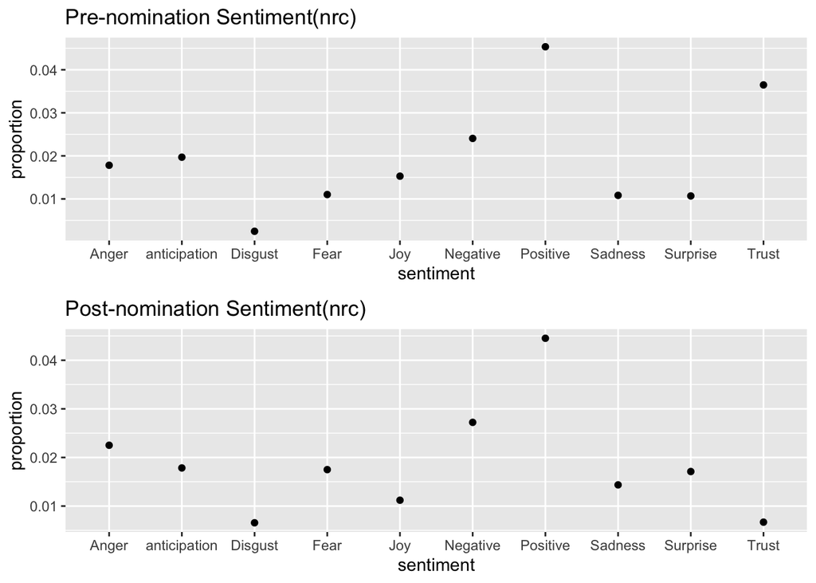

```r
data_nrc_pre <- data.frame(sentiment = c("Trust","Fear","Negative","Sadness","Anger","Surprise","Positive","Disgust","Joy","anticipation"), proportion = c(sum(nrcFeat_pre$nrcTrust)/nrow(tword_pre),
                                    sum(nrcFeat_pre$nrcFear)/nrow(tword_pre),
                                    sum(nrcFeat_pre$nrcNegative)/nrow(tword_pre),
                                    sum(nrcFeat_pre$nrcSadness)/nrow(tword_pre),
                                    sum(nrcFeat_pre$nrcAnger)/nrow(tword_pre),
                                    sum(nrcFeat_pre$nrcSurprise)/nrow(tword_pre),
                                    sum(nrcFeat_pre$nrcPositive)/nrow(tword_pre),
                                    sum(nrcFeat_pre$nrcDisgust)/nrow(tword_pre),
                                    sum(nrcFeat_pre$nrcJoy)/nrow(tword_pre),
                                    sum(nrcFeat_pre$nrcanticipation)/nrow(tword_pre)))
data_nrc_post <- data.frame(sentiment = c("Trust","Fear","Negative","Sadness","Anger","Surprise","Positive","Disgust","Joy","anticipation"), proportion = c(sum(nrcFeat_pre$nrcTrust)/nrow(tword_post),
                                    sum(nrcFeat_post$nrcFear)/nrow(tword_post),
                                    sum(nrcFeat_post$nrcNegative)/nrow(tword_post),
                                    sum(nrcFeat_post$nrcSadness)/nrow(tword_post),
                                    sum(nrcFeat_post$nrcAnger)/nrow(tword_post),
                                    sum(nrcFeat_post$nrcSurprise)/nrow(tword_post),
                                    sum(nrcFeat_post$nrcPositive)/nrow(tword_post),
                                    sum(nrcFeat_post$nrcDisgust)/nrow(tword_post),
                                    sum(nrcFeat_post$nrcJoy)/nrow(tword_post),
                                    sum(nrcFeat_post$nrcanticipation)/nrow(tword_post)))

nrc1 <- ggplot(data_nrc_pre, aes(x = sentiment, y = proportion)) + geom_point() + ggtitle('Pre-nomination Sentiment(nrc)')
nrc2 <- ggplot(data_nrc_post, aes(x = sentiment, y = proportion)) + geom_point() + ggtitle('Post-nomination Sentiment(nrc)')
grid.arrange(nrc1, nrc2, nrow=2)
```